# CV_Elisa_Gaspar

Elisa Gaspar

2024-04-02

## Curriculum Vitae

### Datos personales

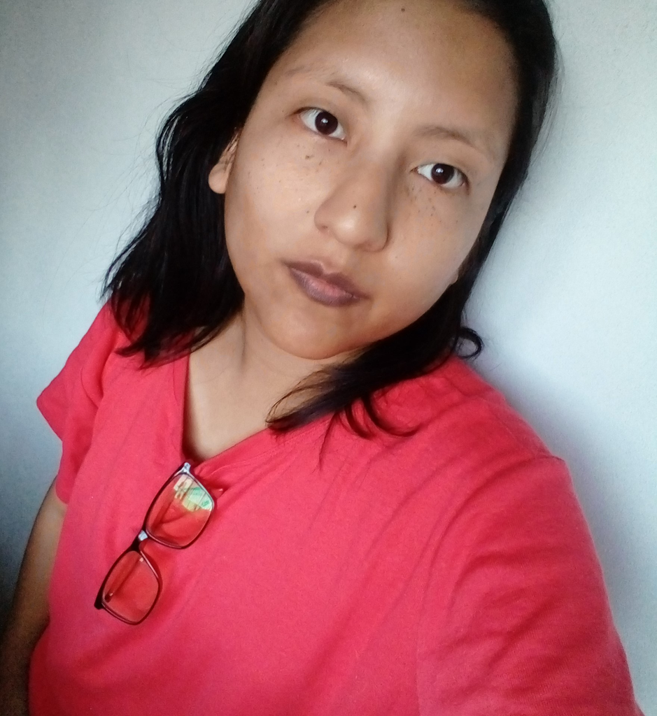

Foto

### Formación

- Licenciatura en Geología. Universidad Nacional de Río Negro. 2023
- Diplomado en Geociencias. Universidad Nacional de Río Negro. 2019

### Cursos

- Escuela de verano Red ChArCo. Estudio microbiológico y molecular de los recursos hídricos continentales de la Patagonia. Universidad Nacional de Río Negro-Universidad de San Sebastián. 2024
- Phyton. Pensar con datos. Instituto de Formación Política y Gestión Pública. 2023
- Curso de inglés nivel pre-intermedio. Patagonian English Institute. 2023
- Geología aplicada al diseño de presas. Asociación Argentina de Geología Aplicada a la Ingeniería. 2023
- Taller Principios básicos de Geoestadística. Facultad de Ciencias Exactas y Físicas Naturales. Colegio Profesional de Geólogos de la Provincia de Córdoba. 2022
- Curso de formación en Ambiente, Higiene y Seguridad laboral en la industria del Petróleo y Gas. UNRN-YPF. 2021
- Curso de Sensores Remotos y su aplicación en Geología. UBA. 2021
- Taller de Morfometría aplicado a Geociencias. Colegio Profesional de Geólogos de la Provincia de Córdoba. 2021
- Taller Introducción a los Sistemas de Información Geográfica utilizando QGIS. Centro argentino de cartografía. 2021
- Taller de Procesamiento de Imágenes Multiespectrales Sentinel 2 con SNAP. Centro argentino de cartografía. 2021
- OIL & GAS from exploration to distribution. IFP School-Fundación YPF. 2019

### Experiencia laboral

| Desde | Hasta | Cargo | Lugar de trabajo |
| --- | --- | --- | --- |
| Diciembre 2023 | Febrero 2024 | Profesora de física | CENS N°22 |
| Septiembre 2023 | Noviembre 2023 | Profesora de física | ESRN N° 116 |
| Junio 2021 | Agosto 2021 | Pasante | Revista de la Asociación Geológica Argentina |

### Contacto

- Correo elisagaspar994@gmail.com
- Celular *2984128060*
- LinkedIn https://www.linkedin.com/in/elisagaspar/